# Laboratorio 04

## geom_point

#### 1. Quais são os aspectos estéticos (aesthetics) exigidos (obrigatórios) da função geom_point()?

##### Resposta:

```
        As variáveis X e Y.
```

#### 2. Faça um gráfico de dispersão do preço (price) pela variável quilates (carat). Utilize as funções xlab() e ylab() para trocar os labels dos eixos x e y, respectivamente.

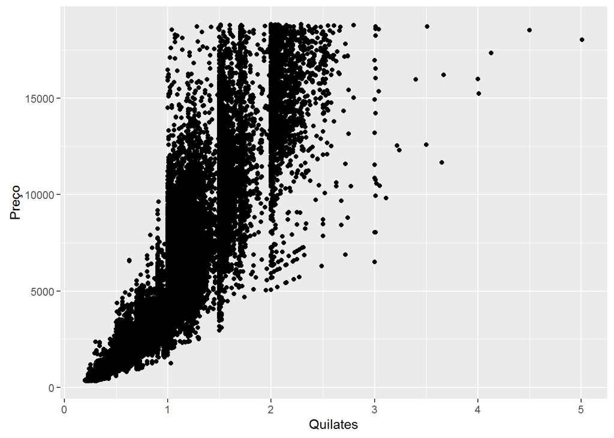

```r
  graph <-
ggplot(diamonds) +
  geom_point(aes(x = carat, y = price))

graphExe1 <-
  graph + xlab("Quilates") +
  ylab("Preço")

graphExe1
```

#### 3. Utilize a facets para fazer gráficos de dispersão do preço pela variável quilate (o mesmo gráfico do exercício 1) para cada nível da variável claridade (clarity).

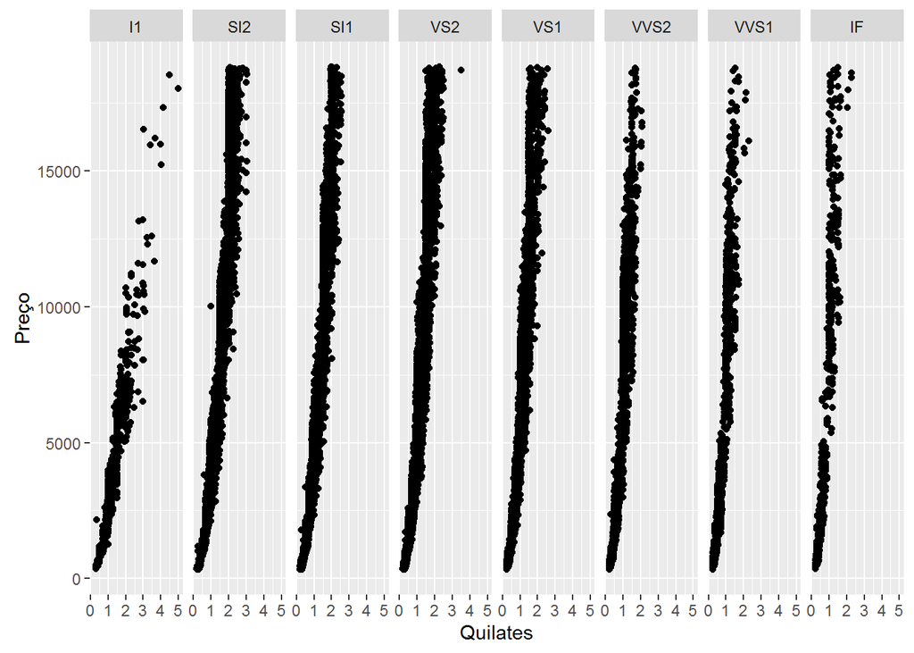

```r
  graph <-
ggplot(diamonds) +
  geom_point(aes(x = carat, y = price))

graph <-
ggplot(diamonds) +
  geom_point(aes(x = carat, y = price))

graphExe2 <-
  graph + xlab("Quilates") +
  ylab("Preço") + facet_grid(~clarity)

graphExe2
```

## geom_histogram

#### 4. Quais são os aspectos estéticos (aesthetics) exigidos (obrigatórios) da função geom_histogram()?

##### Resposta:

```
        A variável X.
```

#### 5. Faça um histograma da variável preço. Modifique a cor das barras de forma que elas não pareçam grudadas umas nas outras.

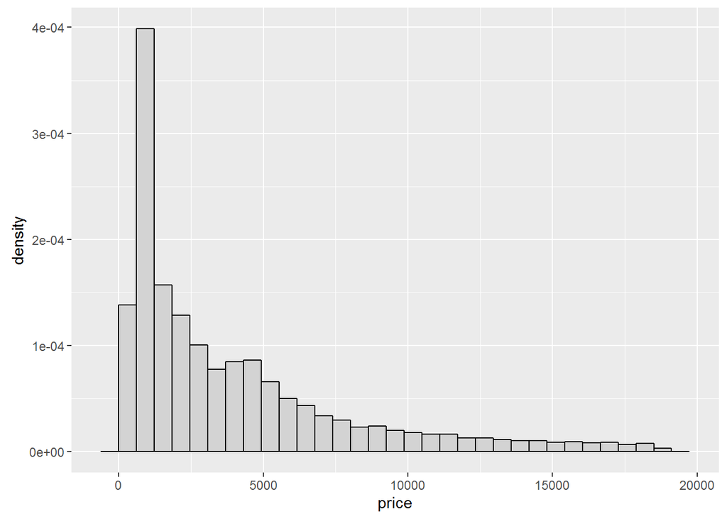

```r
graphHist <-
ggplot(data = diamonds, aes(x = price, y = ..density..)) +
  geom_histogram(color = 'black', fill = 'light grey')
graphHist
```

#### 6. Utilize a função geom_density() para adicionar ao gráfico anterior uma estimativa suavizada da densidade.

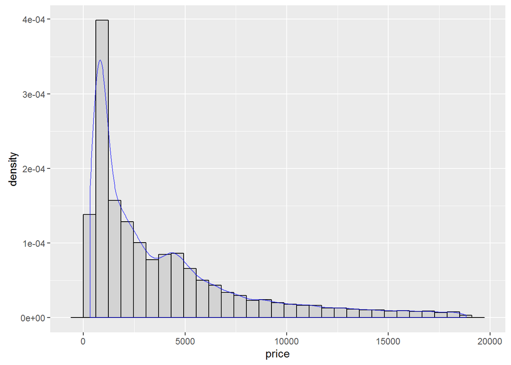

```r
graphHist +
  geom_density(alpha = 0.6, color = "Blue")
```

## geom_boxplot

#### 7. Quais são os aspectos estéticos (aesthetics) exigidos (obrigatórios) da função geom_boxplot()?

##### Resposta:

```
        Os aspectos: lower, middlle, upper, x, ymax, ymin
```

#### 8. Faça boxplots da variável preço coloridos de acordo com a variável corte (cut).

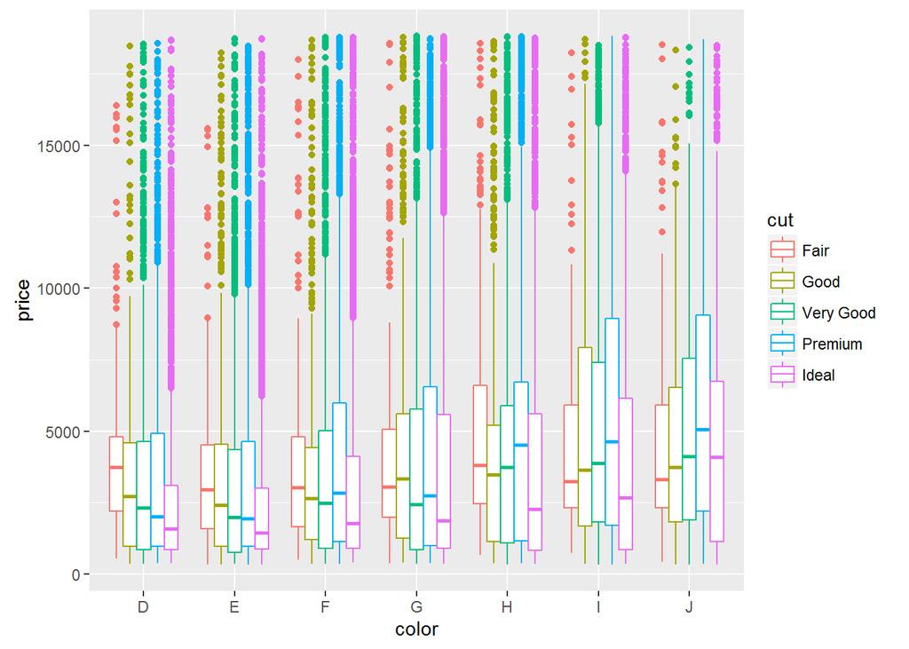

```r
graphHist <-
  ggplot(diamonds, aes(x = color, y = price, color = cut)) +
  geom_boxplot() +
  scale_fill_manual(values=c("#999999", "#E69F00", "#56B4E9", "dark green", "purple"))
graphHist
```

#### 9. Substitua as cores padrões e remova a legenda do gráfico anterior. (Dica: use a função scale_color_manual)

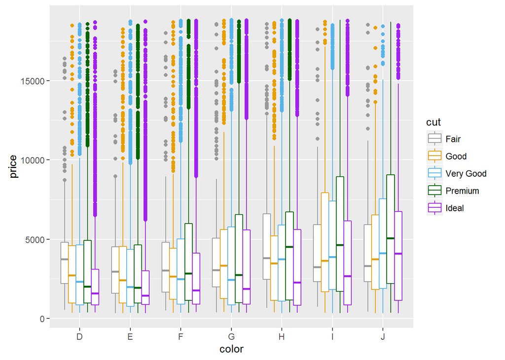

```r
graph2 <-
graphHist +
  scale_color_manual(values=c("#999999", "#E69F00", "#56B4E9", "dark green", "purple"))

graph2
```

## geom_bar

#### 10. Quais são os aspectos estéticos (aesthetics) exigidos (obrigatórios) da função geom_bar()?

##### Resposta:

```
        A variável/aspecto estético X.
```

#### 11. Faça um gráfico de barras do número de diamantes em cada categoria da variável cor (color).

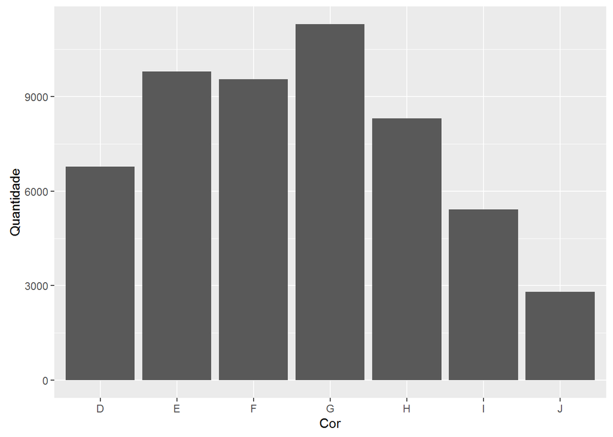

```r
graph <-
  ggplot(diamonds) +
  geom_bar(aes(x = color)) +
  ylab("Quantidade") +
  xlab("Cor")
graph
```

# BD ECONOMICS:

#### 12. Faça um gráfico de dispersão do número de desempregados (eixo x) pelo tempo médio de desemprego (eixo y). Não se esqueça de alterar o label dos eixos.

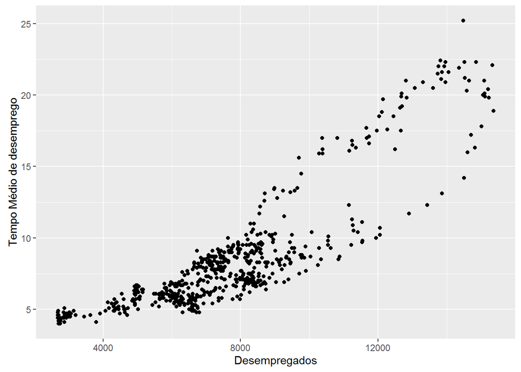

```r
graph <- ggplot(data = economics, aes(x = unemploy, y = uempmed)) +
  geom_point() +
  xlab("Desempregados") + ylab("Tempo Médio de desemprego")

graph
```

#### 13. Faça o mesmo gráfico do exercício anterior, no entanto, os pontos devem ter cores diferentes para cada ano, seguindo uma escala contínua.

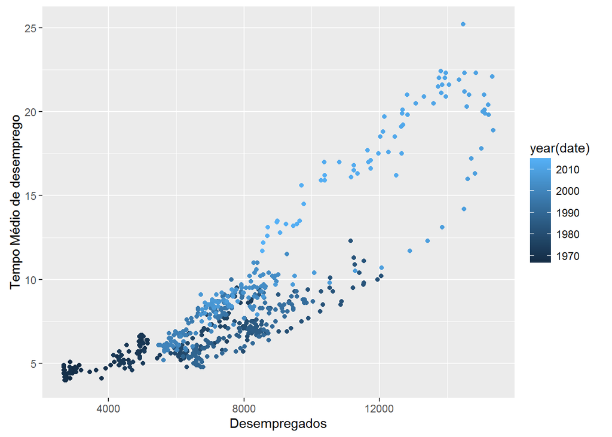

```r
graph +
  geom_point(aes(color = year(date)))
```

#### 14. Faça um gráfico de linha do número de desempregados (eixo y) e a data (eixo x).

```r
graph <- ggplot(data = economics, aes(x = date, y = unemploy)) +
  geom_line() +
  xlab("Data") + ylab("Desempregados")
```

[output not shown]

#### 15. Repita o gráfico anterior, no entanto desta vez a periodicidade deve ser anual e o valor apresentado no eixo y deve ser o número médio de desempregados.

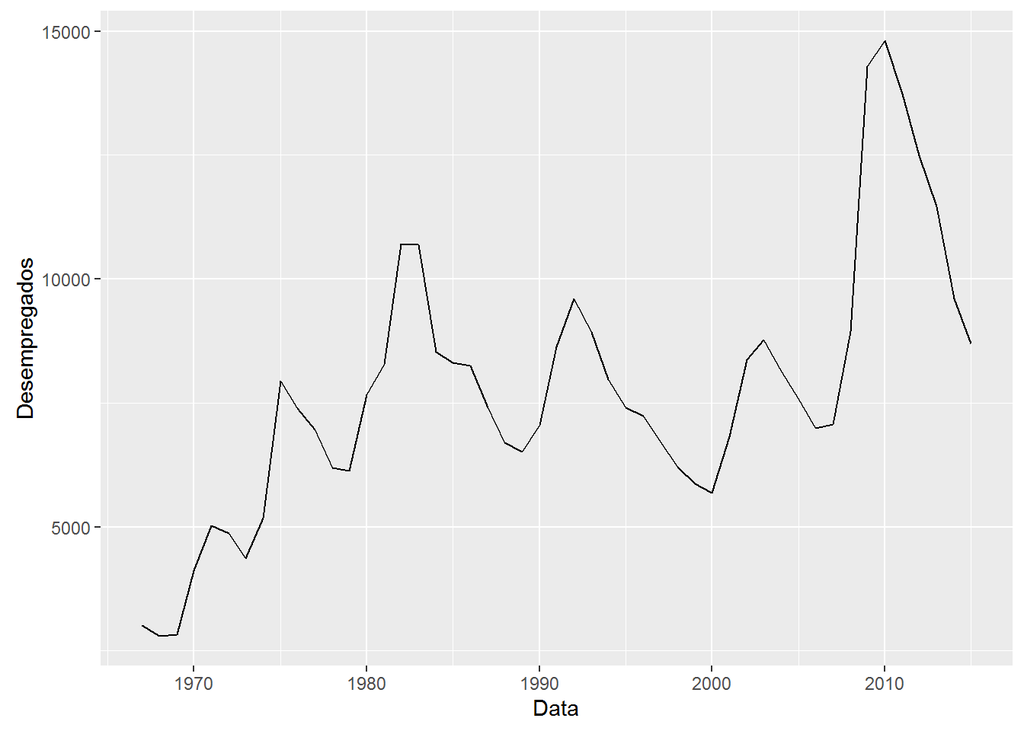

```r
dt_economics <-
  economics %>% select(date, unemploy) %>%
  group_by(ano = year(date)) %>% summarise(desemp = mean(unemploy))

graph <- ggplot(data = dt_economics, aes(x = ano, y = desemp)) +
  geom_line() +
  xlab("Data") + ylab("Desempregados")

graph
```

#### 16.Tente reproduzir o seguinte gráfico:

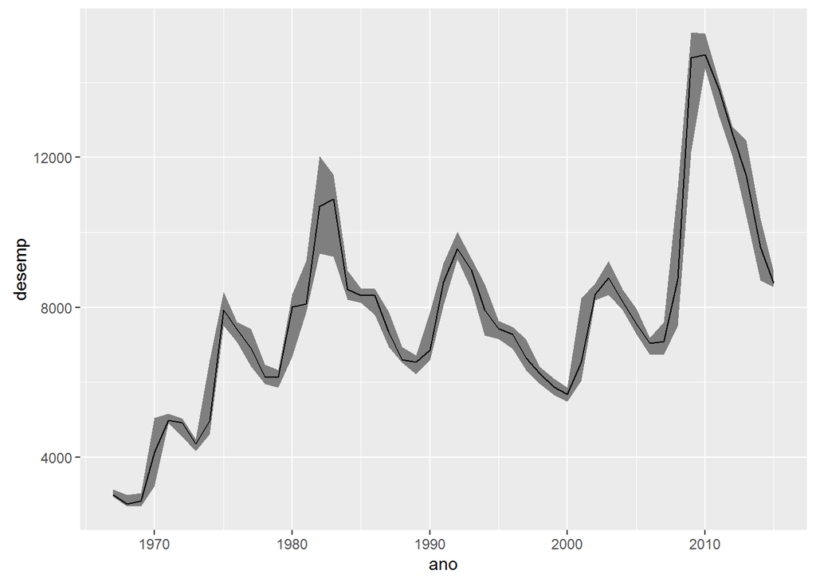

```r
dt_economics <-
  economics %>% select(date, unemploy) %>%
  group_by(ano = year(date)) %>% summarise(desemp = median(unemploy), lim_inf = quantile(unemploy, probs = c(0.01), na.rm = TRUE), lim_sup = quantile(unemploy, probs = c(0.99), na.rm = TRUE))

graph <- ggplot(data = dt_economics, aes(x = ano, y = desemp)) +
  geom_ribbon(aes(ymin = lim_inf, ymax = lim_sup), fill = "grey50") +
  geom_line()

graph
```

#### 17. Afim de comparar a evolução no tempo dos índices pce, psaver e taxa de desemprego (unemploy/pop), tente refazer o seguinte gráfico.

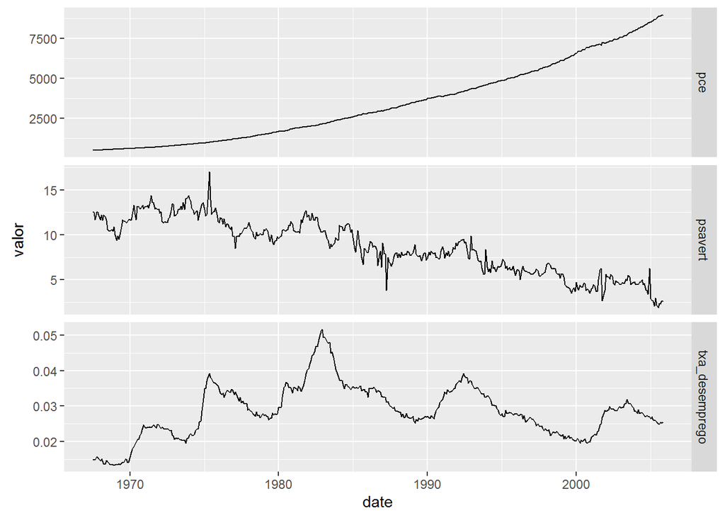

```r
dt_economics <-
  economics %>%
  mutate(txa_desemprego = (unemploy/pop)) %>% select(date, pce, psavert, txa_desemprego) %>% filter(pce < 9000)

dt_economics <-
dt_economics %>%  gather(tipo, valor, -date)

graph <-
  ggplot(data = dt_economics, aes(x = date, y = valor)) +
  geom_line() + facet_grid(tipo ~ ., scales = "free_y")
graph
```